# R Notebook

## Notame workflow

```r
# Notame package installation
#if (!requireNamespace("devtools", quietly = TRUE)) {
#  install.packages("devtools")
#}
#devtools::install_github("antonvsdata/notame", ref = "v0.3.1")

#Library´s
library(usethis)
library(devtools)
library(shiny)
library(foreach)
library(iterators)
library(parallel)
library(ggplot2)
library(doParallel)
library(magrittr)
library(tidyverse)
library(patchwork)
library(dplyr)
library(here)
library(gplots)
library(notame)
library(doParallel)
#remotes::install_gitlab("CarlBrunius/batchCorr")
library(batchCorr)
library(ggplot2)
#install.packages("ggrepel")
library(ggrepel)
#install.packages("hexbin")
library(hexbin)
#install.packages("Hmisc")
library(Hmisc)

# Notame library call
library(notame)

# Dependency packages installation
install_dependencies
```

Then, a main path and a log system was added to have a record of each process executed.

```r
# Main path
ppath <- "E:/Paper/results"
# Log system
init_log(log_file = 'E:/Paper/results/log_LC-MS_Negative_3.txt')
```

```r
data <- read_from_excel(file = "E:/Paper/results/Libro3.xlsx", sheet = 4,
                        corner_row = 9, corner_column = "I",
                        split_by = c("Column", "Ion Mode"))
```

```
INFO [2025-04-03 16:56:34] Corner detected correctly at row 9, column I
INFO [2025-04-03 16:56:34]
Extracting sample information from rows 1 to 9 and columns J to DF
INFO [2025-04-03 16:56:34] Replacing spaces in sample information column names with underscores (_)
INFO [2025-04-03 16:56:34] Naming the last column of sample information "Datafile"
INFO [2025-04-03 16:56:34]
Extracting feature information from rows 10 to 1765 and columns A to I
INFO [2025-04-03 16:56:34] Creating Split column from Column, Ion Mode
INFO [2025-04-03 16:56:34] Feature_ID column not found, creating feature IDs
INFO [2025-04-03 16:56:34] Identified m/z column row m/z and retention time column row retention time
INFO [2025-04-03 16:56:34] Identified m/z column row m/z and retention time column row retention time
INFO [2025-04-03 16:56:34] Creating feature IDs from Split, m/z and retention time
INFO [2025-04-03 16:56:34] Replacing dots (.) in feature information column names with underscores (_)
INFO [2025-04-03 16:56:34]
Extracting feature abundances from rows 10 to 1765 and columns J to DF
INFO [2025-04-03 16:56:34]
Checking sample information
INFO [2025-04-03 16:56:34] QC column generated from rows containing 'QC'
INFO [2025-04-03 16:56:34] Sample ID autogenerated from injection orders and prefix ID_
INFO [2025-04-03 16:56:34] Checking that feature abundances only contain numeric values
INFO [2025-04-03 16:56:34]
Checking feature information
INFO [2025-04-03 16:56:34] Checking that feature IDs are unique and not stored as numbers
INFO [2025-04-03 16:56:34] Checking that m/z and retention time values are reasonable
INFO [2025-04-03 16:56:34] Identified m/z column row_m_z and retention time column row_retention_time
INFO [2025-04-03 16:56:34] Identified m/z column row_m_z and retention time column row_retention_time
```

```r
modes <- construct_metabosets(exprs = data$exprs,
                              pheno_data = data$pheno_data,
                              feature_data = data$feature_data,
                              group_col = "Group")
```

```
Initializing the object(s) with unflagged features
INFO [2025-04-03 16:56:36]
Checking feature information
INFO [2025-04-03 16:56:36] Checking that feature IDs are unique and not stored as numbers
INFO [2025-04-03 16:56:36] Checking that feature abundances only contain numeric values
INFO [2025-04-03 16:56:36] Setting row and column names of exprs based on feature and pheno data
```

Raw data inspection.

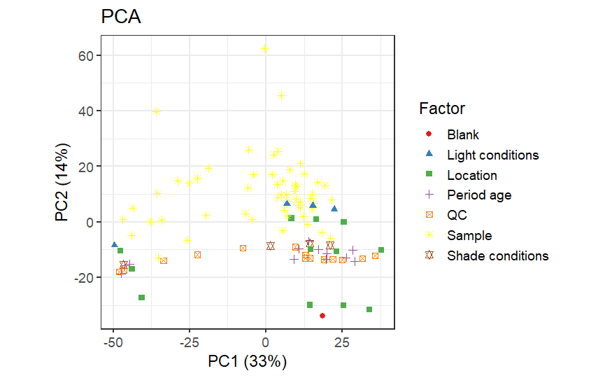

```r
# Data extraction
mode_test <- modes$RP_NEG
# Boxplot of raw data
raw_bp <- plot_sample_boxplots(mode_test,
                               order_by = "Factor",
                               fill_by = "Factor")
# PCA of raw data
raw_pca <- plot_pca(mode_test,
                    center = TRUE,
                    shape = "Factor",
                    color = "Factor")
# Package to plots visualization in a same windows
#if (!requireNamespace("devtools", quietly = TRUE)) {
#  install.packages("devtools")
#}
#devtools::install_github("thomasp85/patchwork")
library(patchwork)
# Plot
raw_pca
```

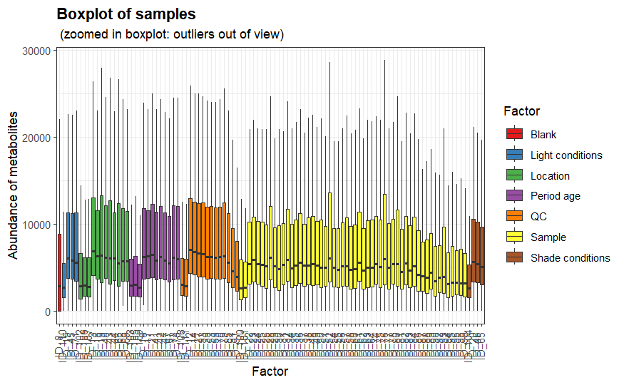

```r
raw_bp
```

## Preprocessing

```r
# Data extraction
mode <- modes$RP_NEG
# Change 0 value to NA
mode <- mark_nas(mode, value = 0)
```

```r
# Low detection rate
mode <- flag_detection(mode, qc_limit = 12/14, group_limit = 2/3)
```

```
INFO [2025-04-03 16:56:54]
1% of features flagged for low detection rate
```

```r
# Some statistics after low detection algorithm
#visualizations(mode,
#               prefix = paste0(ppath,
#                               "Result/notame_Result/HS_GCMS/Figure/",
#                               "Low_Detection")
#               )
```

```r
# Drift correction
corrected <- correct_drift(mode)
```

```
INFO [2025-04-03 16:56:57]
Starting drift correction at 2025-04-03 16:56:57.693488
INFO [2025-04-03 16:57:03] Drift correction performed at 2025-04-03 16:57:03.93638
INFO [2025-04-03 16:57:05] Inspecting drift correction results 2025-04-03 16:57:05.912357
INFO [2025-04-03 16:57:11] Drift correction results inspected at 2025-04-03 16:57:11.012208
INFO [2025-04-03 16:57:11]
Drift correction results inspected, report:
Drift_corrected: 100%,  Missing_QCS: 0%
```

```r
# Flag low quality features
corrected <- flag_quality(corrected,
                          condition = "RSD_r < 0.15 & D_ratio_r < 0.86")
```

```
INFO [2025-04-03 16:57:11]
18% of features flagged for low quality
```

```r
# Exporting data to inspect drift correction
#write_to_excel(corrected,
#               "E:/Paper/results/MZmine_drifft_1.xlsx")
```

Then we can visualize the data after drift correction.

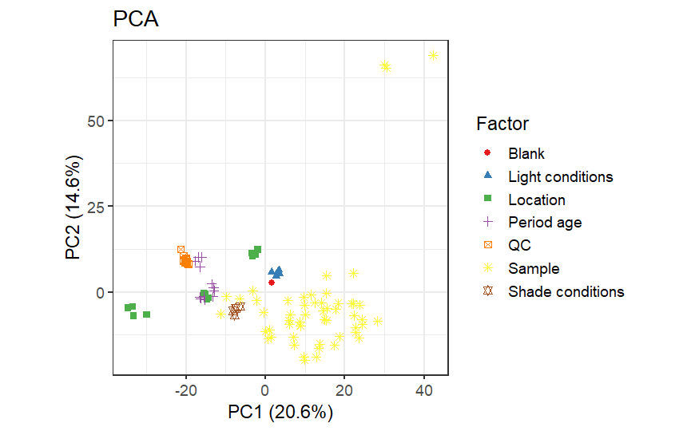

```r
# Boxplot
corr_bp <- plot_sample_boxplots(corrected,
                                order_by = "Factor",
                                fill_by = "Factor")
# PCA
corr_pca <- plot_pca(corrected,
                     center = TRUE,
                     shape = "Factor",
                     color = "Factor")
# Plot
corr_pca
```

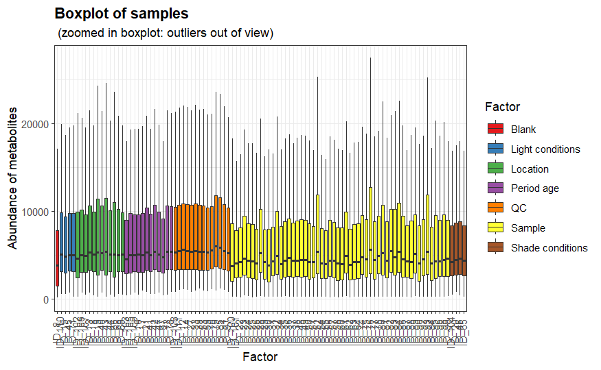

```r
corr_bp
```

```r
# Removal of contaminants
corrected_blank <- flag_contaminants(corrected,
                                        blank_col = "Group",
                                        blank_label = "Blank",
                                        flag_thresh = 0.80,
                                        flag_label = "Contaminant")
```

```
INFO [2025-04-03 16:57:39]
29% of features flagged as contaminants
```

```r
# Removal blank group from dataset
corrected_blank <- corrected_blank[, corrected_blank$Group != "Blank"]
pData(corrected_blank) <- droplevels(pData(corrected_blank))
# Exporting data to clean identified features
#write_to_excel(corrected_blank,
#               "E:/Paper/results/MZmine_corrected_no_blank_1.xlsx")
```

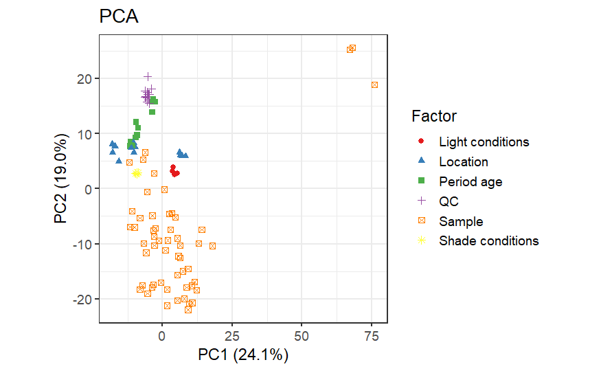

```r
# Boxplot
blank_bp <- plot_sample_boxplots(corrected_blank,
                                 order_by = "Factor",
                                 fill_by = "Factor")
# PCA
blank_pca <- plot_pca(corrected_blank,
                      center = TRUE,
                      shape = "Factor",
                      color = "Factor")
# Plot
blank_pca
```

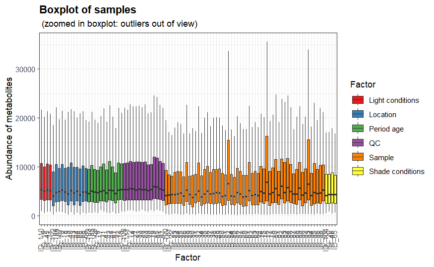

```r
blank_bp
```

```r
#More stadistics
# Some statistics after low detection algorithm
#visualizations(corrected_blank,
#               prefix = paste0(ppath,
#                               "/LC_MS-driff/Figure",
#                               "Low_Detection")
#)
```

```r
clustered <- cluster_features(corrected_blank,
                              rt_window = 1/260,
                              corr_thresh = 0.95,
                              d_thresh = 0.8,
                              #plotting = FALSE,
                              #prefix = paste0(ppath, "/HS_GCMS/Figure","Cluster")
)
```

```
INFO [2025-04-03 16:57:48] Identified m/z column row_m_z and retention time column row_retention_time
INFO [2025-04-03 16:57:48]
Starting feature clustering at 2025-04-03 16:57:48.175426
INFO [2025-04-03 16:57:48] Finding connections between features in RP_NEG
[1] 100
[1] 200
[1] 300
[1] 400
[1] 500
[1] 600
[1] 700
[1] 800
[1] 900
INFO [2025-04-03 16:58:14] Found 1481 connections in RP_NEG
INFO [2025-04-03 16:58:14] Found 1481 connections
56 components found

41 components found

22 components found

11 components found

INFO [2025-04-03 16:58:15] Found 84 clusters of 2 or more features, clustering finished at 2025-04-03 16:58:15.279764
```

```r
compressed <- compress_clusters(clustered)
```

```
INFO [2025-04-03 16:58:15] Clusters compressed, left with 663 features
```

```r
# Exporting data to inspect cluster features
write_to_excel(clustered,
               "E:/Paper/results/MZmine_clustered_no_blank_cluster_4.xlsx")
```

```
INFO [2025-04-03 16:58:15] Moved Datafile column to last to get meaningful column names for abundances
```

```r
# Exporting data to inspect compressed features
write_to_excel(compressed,
               "E:/Paper/results/MZmine_compressed_no_blank_cluster_4.xlsx")
```

```
INFO [2025-04-03 16:58:17] Moved Datafile column to last to get meaningful column names for abundances
```

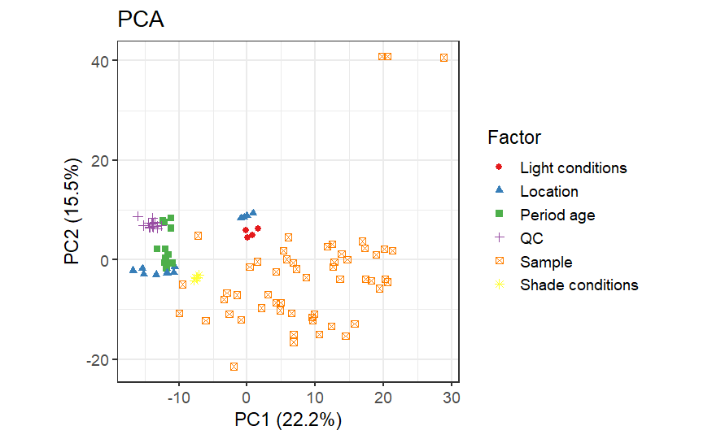

```r
# Boxplot
clust_bp <- plot_sample_boxplots(compressed,
                                 order_by = "Factor",
                                 fill_by = "Factor")
# PCA
clust_pca <- plot_pca(compressed,
                      center = TRUE,
                      shape = "Factor",
                      color = "Factor")
# Plot
clust_pca
```

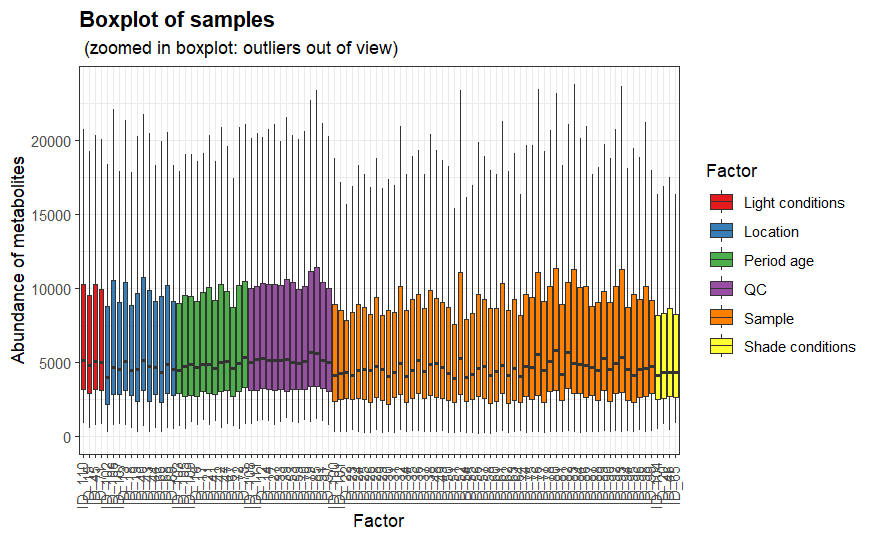

```r
clust_bp
```

```r
#save(imputed, file = paste0(ppath, "Result/notame_Result/HS_GCMS/Notame_HS_GC-MS_out.RData"))
```

# PCA plots

Here read this paper: https://doi.org/10.1007%2Fs11306-016-1030-9

```r
# Impute missing values using random forest
# To clean data
set.seed(698)
imputed <- impute_rf(compressed)
# To all data
imputed <- impute_rf(imputed, all_features = TRUE)
```

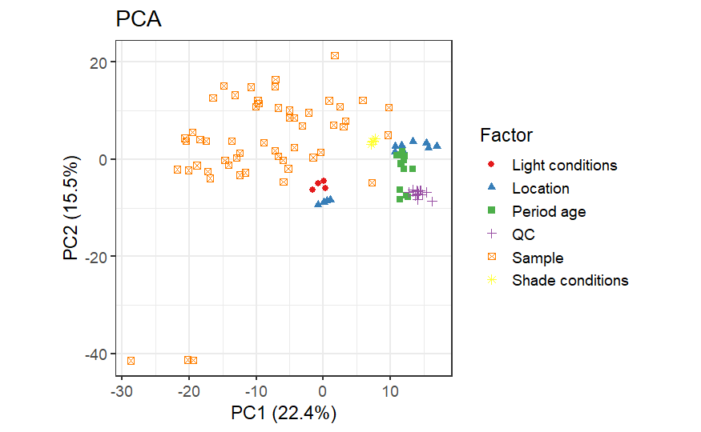

```r
# Boxplot
imp_bp <- plot_sample_boxplots(imputed,
                               order_by = "Factor",
                               fill_by = "Factor")
# PCA
imp_pca <- plot_pca(imputed,
                    center = TRUE,
                    shape = "Factor",
                    color = "Factor")
# Plot
imp_pca
```

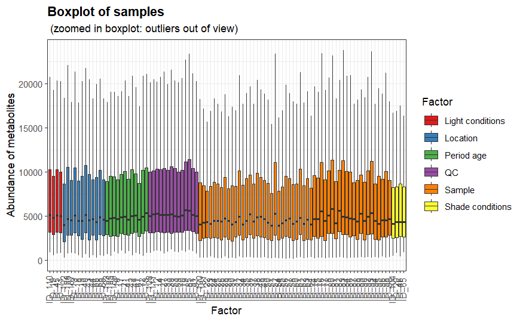

```r
imp_bp
```

```r
# Probabilistic quotient normalization
pqn_set <- pqn_normalization(imputed,
                             ref = c("qc", "all"),
                             method = c("median", "mean"),
                             all_features = FALSE)
```

```
INFO [2025-04-03 17:13:05] Starting PQN normalization
INFO [2025-04-03 17:13:05] Using median of qc samples as reference spectrum
```

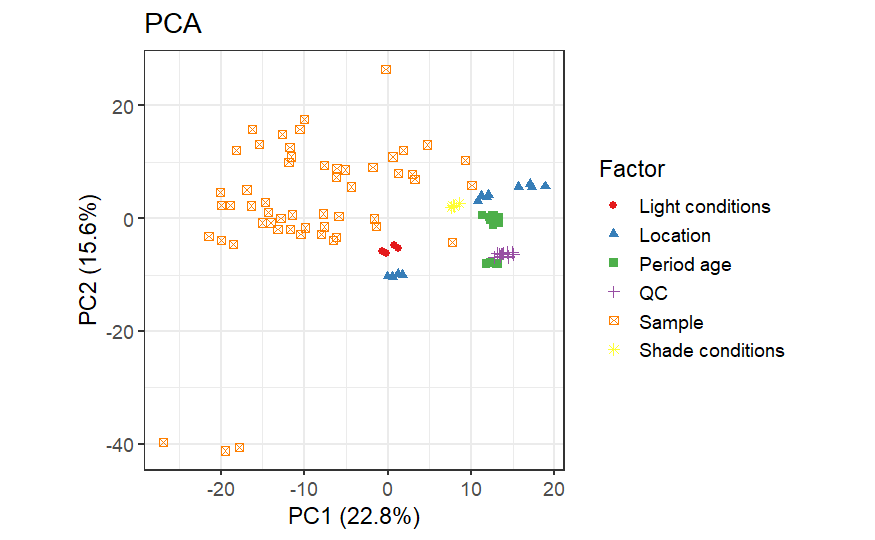

```r
# Boxplot
pqn_bp <- plot_sample_boxplots(pqn_set,
                               order_by = "Factor",
                               fill_by = "Factor")
# PCA
pqn_pca <- plot_pca(pqn_set,
                    center = TRUE,
                    shape = "Factor",
                    color = "Factor")
# Plot
pqn_pca
```

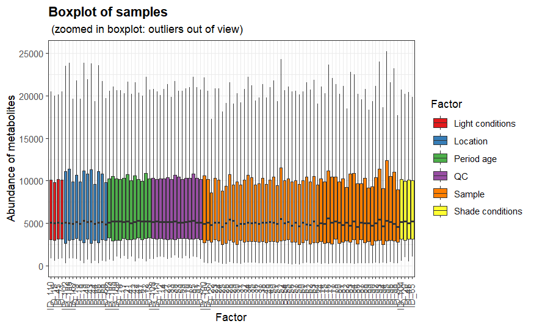

```r
pqn_bp
```

```r
# Extract clean data
ppm_noflag <- drop_flagged(pqn_set)
# "SummarizedExperiment" package installation
#if (!require("BiocManager", quietly = TRUE))
#    install.packages("BiocManager")
#BiocManager::install("SummarizedExperiment")
library(SummarizedExperiment)
# Convert feature height table to SummarizedExperiment class
pmp_data <- SummarizedExperiment(assays = exprs(ppm_noflag),
                                 colData = ppm_noflag@phenoData@data)
# Package for generalized logarithmic transform
#if (!requireNamespace("BiocManager", quietly = TRUE))
#    install.packages("BiocManager")
#BiocManager::install("pmp")
library(pmp)
# Generalised logarithmic transform
glog_exprs <- glog_transformation(df = pmp_data@assays@data@listData[[1]],
                                  classes = pmp_data$QC,
                                  qc_label = "QC")
# Adding glog transformation to notame MetaboSet
glog_set <- ppm_noflag
exprs(glog_set) <- glog_exprs
```

# Volcano Plot

```r
# Removal of sample group from the dataset
volc_glog <- glog_set[, glog_set$Analysis_group != "Sample"]
pData(volc_glog) <- droplevels(pData(volc_glog))
# Drop QC
volc_glog <- drop_qcs(volc_glog)
# Extracting SubQC light factor
volc_glog <- volc_glog[, volc_glog$Light_Factor != "Other enviroment factors"]
pData(volc_glog) <- droplevels(pData(volc_glog))
```

```r
# Removal of sample group from the dataset
volc_pqn <- ppm_noflag[, ppm_noflag$Analysis_group != "Sample"]
pData(volc_pqn) <- droplevels(pData(volc_pqn))
# Drop QC
volc_pqn <- drop_qcs(volc_pqn)
# Extracting SubQC light factor
volc_pqn <- volc_pqn[, volc_pqn$Light_Factor != "Other enviroment factors"]
pData(volc_pqn) <- droplevels(pData(volc_pqn))
```

```r
# Performing homoscedasticity test
volc_th <-
  perform_homoscedasticity_tests(volc_glog,
                                 formula_char = "Feature ~ Light_Factor")
```

```
INFO [2025-04-03 17:13:24] Starting homoscedasticity tests.
INFO [2025-04-03 17:13:28] Homoscedasticity tests performed.
```

```r
# Library to left_join use
library(dplyr)
# Fold change between shade and light levels
volc_fc <- fold_change(volc_pqn, group = "Light_Factor")
```

```
INFO [2025-04-03 17:13:30] Starting to compute fold changes.
INFO [2025-04-03 17:13:30] Fold changes computed.
```

```r
# two-sample t-test performing
volc_t <- perform_t_test(volc_glog,
                         formula_char = "Feature ~ Light_Factor",
                         var.equal = TRUE)
```

```
Remember that t.test returns difference between group means in different order than lm.
This function mimics this behavior, so the effect size is mean of reference level minus mean of second level.
```

```
INFO [2025-04-03 17:13:32] Starting t-tests for Light & Shade
INFO [2025-04-03 17:13:34] t-tests performed.
```

```r
# Adding the fold change to the t-test data
volc_data <- left_join(volc_t, volc_fc)
# Log-transform for visualization
volc_data$logP <- -log10(volc_data$Light_vs_Shade_t_test_P)
volc_data$log2_fc <- log2(volc_data$Shade_vs_Light_FC)
```

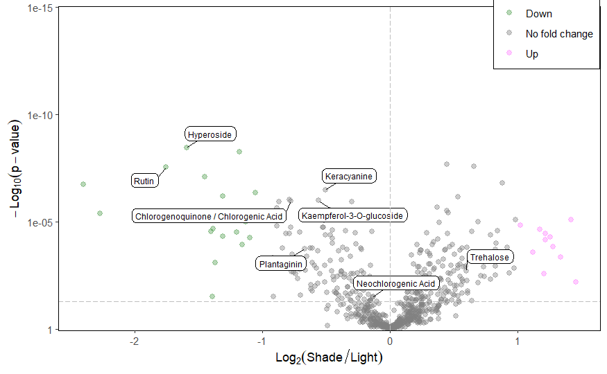

```r
# Determine point colors based on significance and fold change
volc_data <- volc_data %>%
  mutate(point_color = case_when(
    Light_vs_Shade_t_test_P < 0.05 & log2_fc < -1 ~ "Down", # significantly down
    Light_vs_Shade_t_test_P < 0.05 & log2_fc > 1 ~ "Up",    # significantly up
    log2_fc < 1 & log2_fc > -1 ~ "No fold change",          # fold change < 2
    Light_vs_Shade_t_test_P > 0.05 & log2_fc < -1 |
      Light_vs_Shade_t_test_P > 0.05 & log2_fc > 1 ~ "Fold change")) # fold change > 2
# Extracting feature identified
metab_data <- glog_set[!is.na(glog_set@featureData@data$Metabolite),]
# Extracting metabolite table
meta_table <- metab_data@featureData@data
# Creating a new small table of the annotated compounds
# Keep metabolites with p-value < 0.05
volc_compouds <- subset(volc_data, Light_vs_Shade_t_test_P < 0.05 |
                             point_color == "Fold change")
volc_compouds <- left_join(meta_table, volc_compouds)
# Volcano plot
vc_plot <- ggplot(volc_data, aes(log2_fc, logP, color = point_color)) +
  geom_point(size = 2, alpha = 0.4) +
  scale_colour_manual(values = c("No fold change" = "#808080",
                                 "Down" = "#4F9D4EFF",
                                 "Up" = "#ff80ff",
                                 "Fold change" = "#F5BC5CFF")) +
  theme_classic() +
  #theme(legend.position = "none") +
  #geom_point(data = volc_compouds,
  #           aes(shape = meta_table$Identification_level,
  #               color = meta_table$Identification_level),
  #           size = 2) +
  labs(#shape = 'Identification level',
       color = 'Color key') +
  ggrepel::geom_label_repel(data = volc_compouds,
                            aes(label = meta_table$Metabolite),
                            color = "black",
                            box.padding = 0.37,
                            label.padding = 0.22,
                            label.r = 0.30,
                            cex = 2.5,
                            max.overlaps = 20,
                            min.segment.length = 0,
                            seed = 42,) +
  xlab(bquote(Log[2](Shade/Light))) + ylab(bquote(-Log[10](p-value))) +
  scale_y_continuous(limits = c(0,15), labels = function(i) 10^-i,
                     expand=c(0.003, 0.003)) +
  theme(legend.position = c(0.90, 0.947),
        legend.background = element_rect(fill = "white", color = "black")) +
  theme(panel.grid = element_blank(),
        panel.border = element_rect(fill= "transparent")) +
  #geom_vline(xintercept = 1, linetype = "longdash", colour="gray") +
  #geom_vline(xintercept = -1, linetype = "longdash", colour="gray") +
  geom_vline(xintercept = 0, linetype = "longdash", colour="gray") +
  geom_hline(yintercept = -log10(0.05), linetype = "longdash", colour="gray")
vc_plot
```

```r
# Save plot
#ggsave('Result/notame_Result/figure_2b.pdf',
#       width = 5, height = 4, device='pdf', dpi="print")
```

```r
# Removal of sample group from the dataset
sp_volc_glog <- glog_set[, glog_set$Analysis_group != "Sub_Quality_Control"]
pData(sp_volc_glog) <- droplevels(pData(sp_volc_glog))
# Drop QC
sp_volc_glog <- drop_qcs(sp_volc_glog)
```

```r
# Removal of sample group from the dataset
sp_volc_pqn <- ppm_noflag[, ppm_noflag$Analysis_group != "Sub_Quality_Control"]
pData(sp_volc_pqn) <- droplevels(pData(sp_volc_pqn))
# Drop QC
sp_volc_pqn <- drop_qcs(sp_volc_pqn)
```

```r
# Performing homoscedasticity test
sp_volc_th <-
  perform_homoscedasticity_tests(sp_volc_glog,
                                 formula_char = "Feature ~ Light_Factor")
```

```
INFO [2025-04-03 17:13:47] Starting homoscedasticity tests.
INFO [2025-04-03 17:13:51] Homoscedasticity tests performed.
```

```r
# Adding homoscedasticity results to notame MetaboSet
sp_volc_glog <- join_fData(sp_volc_glog, sp_volc_th)
# Extracting features with equal variance
sp_volc_ttset <-
  sp_volc_glog[sp_volc_glog@featureData@data$Levene_P > 0.05,]
# Extracting features with unequal variance
sp_volc_wttset <-
  sp_volc_glog[sp_volc_glog@featureData@data$Levene_P < 0.05,]
```

```r
# Fold change between shade and light levels
sp_volc_fc <- fold_change(sp_volc_pqn, group = "Light_Factor")
```

```
INFO [2025-04-03 17:13:56] Starting to compute fold changes.
INFO [2025-04-03 17:13:56] Fold changes computed.
```

```r
# The two-sample t-test performing
sp_volc_tt <- perform_t_test(sp_volc_ttset,
                            formula_char = "Feature ~ Light_Factor",
                            var.equal = TRUE)
```

```
Remember that t.test returns difference between group means in different order than lm.
This function mimics this behavior, so the effect size is mean of reference level minus mean of second level.
```

```
INFO [2025-04-03 17:13:58] Starting t-tests for Light & Shade
INFO [2025-04-03 17:14:00] t-tests performed.
```

```r
# Adding a tag for t-test results
sp_volc_tt <- sp_volc_tt %>%
  mutate(Statistic_test = case_when(
    Feature_ID != 0 ~ "Student's t-test"))
# The Welch's t-test performing
sp_volc_wtt <- perform_t_test(sp_volc_wttset,
                            formula_char = "Feature ~ Light_Factor",
                            var.equal = TRUE)
```

```
Remember that t.test returns difference between group means in different order than lm.
This function mimics this behavior, so the effect size is mean of reference level minus mean of second level.
```

```
INFO [2025-04-03 17:14:01] Starting t-tests for Light & Shade
INFO [2025-04-03 17:14:01] t-tests performed.
```

```r
# Adding a tag for Welch's t-test results
sp_volc_wtt <- sp_volc_wtt %>%
  mutate(Statistic_test = case_when(
    Feature_ID != 0 ~ "Welch's t-test"))
# Merge Welch's t-test and Student's t-test
sp_volc_t <- rbind(sp_volc_tt, sp_volc_wtt)
# Adding the fold change to statistical results
sp_volc_data <- left_join(sp_volc_t, sp_volc_fc)
# Log-transform for visualization
sp_volc_data$logP <- -log10(sp_volc_data$Light_vs_Shade_t_test_P)
sp_volc_data$log2_fc <- log2(sp_volc_data$Shade_vs_Light_FC)
```

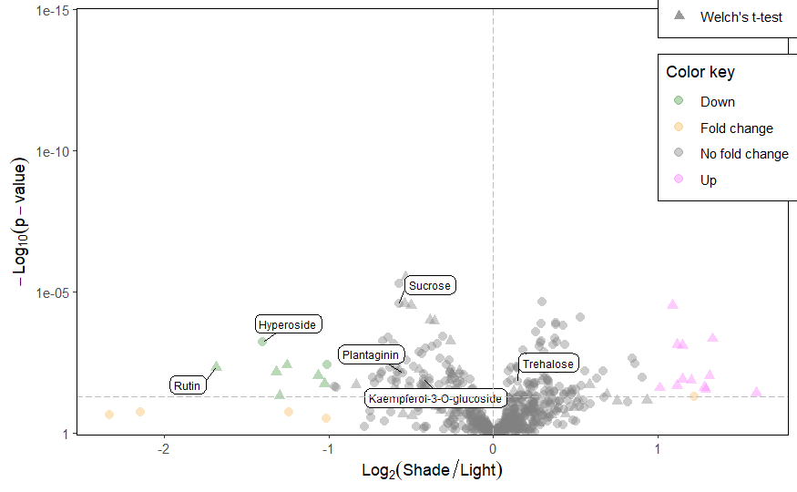

```r
# Determine point colors based on significance and fold change
sp_volc_data <- sp_volc_data %>%
  mutate(point_color = case_when(
    Light_vs_Shade_t_test_P < 0.05 & log2_fc < -1 ~ "Down", # significantly down
    Light_vs_Shade_t_test_P < 0.05 & log2_fc > 1 ~ "Up",    # significantly up
    log2_fc < 1 & log2_fc > -1 ~ "No fold change",          # fold change < 2
    Light_vs_Shade_t_test_P > 0.05 & log2_fc < -1 |
      Light_vs_Shade_t_test_P > 0.05 & log2_fc > 1 ~ "Fold change")) # fold change > 2
# Creating a new small table of the annotated compounds
# Keep metabolites with p-value < 0.05
sp_volc_compouds <- subset(sp_volc_data, Light_vs_Shade_t_test_P < 0.05 |
                             point_color == "Fold change")
sp_volc_compouds <- left_join(meta_table, sp_volc_compouds)
# Volcano plot
sp_vc_plot <- ggplot(sp_volc_data, aes(log2_fc, logP)) +
  #geom_point(size = 2, alpha = 0.4) +
  scale_colour_manual(values = c("No fold change" = "#808080",
                                 "Down" = "#4F9D4EFF",
                                 "Up" = "#ff80ff",
                                 "Fold change" = "#F5BC5CFF")) +
  theme_classic() +
  #theme(legend.position = "none") +
  geom_point(data = sp_volc_data,
             aes(shape = Statistic_test,
                 color = point_color),
             size = 2.5,
             alpha = 0.4) +
  labs(shape = 'Statistical test',
       color = 'Color key') +
  ggrepel::geom_label_repel(data = sp_volc_compouds,
                            aes(label = meta_table$Metabolite),
                            color = "black",
                            box.padding = 0.37,
                            label.padding = 0.22,
                            label.r = 0.30,
                            cex = 2.5,
                            max.overlaps = 20,
                            min.segment.length = 0,
                            seed = 42) +
  xlab(bquote(Log[2](Shade/Light))) + ylab(bquote(-Log[10](p-value))) +
  scale_y_continuous(limits = c(0,15), labels = function(i) 10^-i,
                     expand=c(0.003, 0.003)) +
  theme(legend.position = c(0.915, 0.85),
        legend.background = element_rect(fill = "white", color = "black")) +
  theme(panel.grid = element_blank(),
        panel.border = element_rect(fill= "transparent")) +
  #geom_vline(xintercept = 1, linetype = "longdash", colour="gray") +
  #geom_vline(xintercept = -1, linetype = "longdash", colour="gray") +
  geom_vline(xintercept = 0, linetype = "longdash", colour="gray") +
  geom_hline(yintercept = -log10(0.05), linetype = "longdash", colour="gray")
sp_vc_plot
```

```r
# Save plot
#ggsave(filename = "Result/notame_Result/Figure_s5.pdf", plot = sp_vc_plot,
#       width = 6, height = 5.4, units = "in", dpi = 300, scale = 1.7)
#ggsave(filename = "Result/notame_Result/Figure_s5.png", plot = sp_vc_plot,
#       width = 6, height = 5.4, units = "in", dpi = 300, scale = 1.7)
```

# Tukey

```r
# Drop QC
tk_no_qc <- drop_qcs(glog_set)
# Drop samples
tk_no_sample <- tk_no_qc[, tk_no_qc$Analysis_group != "Sample"]
pData(tk_no_sample) <- droplevels(pData(tk_no_sample))
# Extracting levels of age factor
tk_age <- tk_no_sample[, tk_no_sample$Age_Factor != "Other factor"]
pData(tk_age) <- droplevels(pData(tk_age))
# Extracting identified metabolites
tk_age_set <- tk_age[!is.na(tk_age@featureData@data$Metabolite),]
```

```r
# Extracting feature height table
tk_height <- exprs(tk_age_set)
# Extracting sample information
tk_pdata <- tk_age_set@phenoData@data
tk_pdata <- data.frame(Sample_ID = tk_pdata$Sample_ID,
                       Age_factor = tk_pdata$Age_Factor)
# Extracting feature information
tk_fdata <- tk_age_set@featureData@data
tk_fdata <- data.frame(Feature_ID = tk_fdata$Feature_ID,
                       Metabolite = tk_fdata$Metabolite)
# Transposing feature height table
tk_height <- t(tk_height)
# Feature height table to dataframe
tk_height <- as.data.frame(tk_height)
# Convert the row names to sample ID
tk_height <- tk_height %>%
  mutate(Sample_ID = rownames(tk_height))
# Adding age factor as variable
tk_height <- left_join(tk_pdata, tk_height)
```

```r
# Performing homoscedasticity test
tk_bar_res <-
  perform_homoscedasticity_tests(tk_age_set,
                                 formula_char = "Feature ~ Age_Factor")
```

```
INFO [2025-04-03 17:14:19] Starting homoscedasticity tests.
INFO [2025-04-03 17:14:19] Homoscedasticity tests performed.
```

```r
# Adding a description of the p-value
tk_bar_res <- tk_bar_res %>%
  mutate(bartlett_group = ifelse(Levene_P > 0.05,
                                 "equal variance",
                                 "unequal variance"))
```

```r
# Create two empty vectors to add results
Feature_ID <- c()
anova_pValue <- c()
# Batch analysis
for(i in 3:9) {
  anova_model <- glm(tk_height[, i] ~ tk_height$Age_factor, data = tk_height)
  anova_res <- anova(anova_model, test = "LRT")
  anova_pValue <- c(anova_pValue, anova_res$`Pr(>Chi)`[2])
  Feature_ID <- c(Feature_ID, names(tk_height[i]))
  tk_anova_res <- data.frame(Feature_ID, anova_pValue)
}
# Adding a description of the p-value
tk_anova_res <- tk_anova_res %>%
  mutate(anova_group = ifelse(anova_pValue > 0.05,
                              "Not Significant",
                              "Significant"))
```

```r
# agricolae package installation and library loadding
#install.packages("agricolae", repos = "https://cran.r-project.org")
library(agricolae)
# Create two empty vectors to add results
Feature_ID <- c()
tk_group_early <- c()
tk_group_late <- c()
tk_group_medium <- c()
# Batch analysis
for(i in 3:9) {
  tk_model <- aov(tk_height[, i] ~ tk_height$Age_factor, data = tk_height)
  tk_tes <- HSD.test(tk_model, "tk_height$Age_factor", group = TRUE)
  tk_group_early <- c(tk_group_early, tk_tes[["groups"]]["Early",2])
  tk_group_late <- c(tk_group_late, tk_tes[["groups"]]["Late",2])
  tk_group_medium <- c(tk_group_medium, tk_tes[["groups"]]["Medium",2])
  Feature_ID <- c(Feature_ID, names(tk_height[i]))
  tk_res <- data.frame(Feature_ID, tk_group_early, tk_group_late,
                       tk_group_medium)
  tk_res
}
```

```r
# Merge all results obtained in the Tukey test
tk_result <- left_join(tk_bar_res, tk_anova_res)
```

```r
tk_result <- left_join(tk_result, tk_res)
```

```r
# Flag metabolites
for(i in 1:10) {
  # Flag "-" metabolites that has unequal variance
  if (tk_result$bartlett_group[i] == "unequal variance") {
        tk_result$tk_group_early[i] <- "-"
        tk_result$tk_group_medium[i] <- "-"
        tk_result$tk_group_late[i] <- "-"
  }
  # Flag "ns" metabolites not significant
  if (tk_result$anova_group[i] == "Not Significant" &
      tk_result$bartlett_group[i] == "equal variance") {
        tk_result$tk_group_early[i] <- "ns"
        tk_result$tk_group_medium[i] <- "ns"
        tk_result$tk_group_late[i] <- "ns"
}
 tk_result
}
```

```r
# Tukey table to heatmap
hm_tk_table <- data.frame(Feature_ID = tk_result$Feature_ID,
                          Early = tk_result$tk_group_early,
                          Late = tk_result$tk_group_late,
                          Medium = tk_result$tk_group_medium)
```

```r
# The "gt" package installation
#install.packages("gt")
library(gt)
# Adding metabolite name
tk_table <- left_join(tk_fdata, hm_tk_table)
# Deleting the Feature_ID column
tk_table <- subset(tk_table, select = -c(Feature_ID) )
tk_table <- tk_table |>
  gt() |>
  fmt_markdown(
  columns = everything(),
  rows = everything(),
  md_engine = c("markdown", "commonmark")) |>
  tab_spanner(
    label = "Tukey test",
    columns = 2:4) |>
    tab_source_note(source_note = "Note: Different lowercase letter within the
                  same row indicates significant differences based on Tukey's
                  multiple comparisons (p-value < 0.05, n = 3). '-' represents
                  features with unequal variance according to Levene's test.
                  'ns' are the features that do not have statistical
                  differences (p-value > 0.05) according to the ANOVA test.") |>
  tab_options(table.width = px(750)) |>
  as_raw_html()
tk_table
```

Early

Late

Medium

Neochlorogenic Acid

ns

ns

ns

Quinic acid

ns

ns

ns

Sucrose

ns

ns

ns

Trehalose

ns

ns

ns

Note: Different lowercase letter within the same row indicates significant differences based on Tukey's multiple comparisons (p-value < 0.05, n = 3). '-' represents features with unequal variance according to Levene's test. 'ns' are the features that do not have statistical differences (p-value > 0.05) according to the ANOVA test.

# Tukey Sample´s

```r
# Drop factor pooled (subQC)
tk_no_subqc <- tk_no_qc[, tk_no_qc$Analysis_group != "Sub_Quality_Control"]
pData(tk_no_subqc) <- droplevels(pData(tk_no_subqc))
# Extracting identified metabolites
tk_no_subqc <- tk_no_subqc[!is.na(tk_no_subqc@featureData@data$Metabolite),]
```

```r
# Extracting feature height table
tk_spl_height <- exprs(tk_no_subqc)
# Extracting sample information
tk_spl_pdata <- tk_no_subqc@phenoData@data
tk_spl_pdata <- data.frame(Sample_ID = tk_spl_pdata$Sample_ID,
                           Age_factor = tk_spl_pdata$Age_Factor)
# Extracting feature information
tk_spl_fdata <- tk_no_subqc@featureData@data
tk_spl_fdata <- data.frame(Feature_ID = tk_spl_fdata$Feature_ID,
                           Metabolite = tk_spl_fdata$Metabolite)
# Transposing feature height table
tk_spl_height <- t(tk_spl_height)
# Feature height table to dataframe
tk_spl_height <- as.data.frame(tk_spl_height)
# Convert the row names to sample ID
tk_spl_height <- tk_spl_height %>%
  mutate(Sample_ID = rownames(tk_spl_height))
# Adding age factor as variable
tk_spl_height <- left_join(tk_spl_pdata, tk_spl_height)
```

```r
# Performing homoscedasticity test
tk_spl_bar_res <-
  perform_homoscedasticity_tests(tk_no_subqc,
                                 formula_char = "Feature ~ Age_Factor")
```

```
INFO [2025-04-03 17:14:45] Starting homoscedasticity tests.
INFO [2025-04-03 17:14:45] Homoscedasticity tests performed.
```

```r
# Adding a description of the p-value
tk_spl_bar_res <- tk_spl_bar_res %>%
  mutate(bartlett_group = ifelse(Levene_P > 0.05,
                                 "equal variance",
                                 "unequal variance"))
```

```r
# Create two empty vectors to add results
Feature_ID <- c()
anova_pValue <- c()
# Batch analysis
for(i in 3:12) {
  anova_model <- glm(tk_spl_height[, i] ~ tk_spl_height$Age_factor,
                     data = tk_spl_height)
  anova_res <- anova(anova_model, test = "LRT")
  anova_pValue <- c(anova_pValue, anova_res$`Pr(>Chi)`[2])
  Feature_ID <- c(Feature_ID, names(tk_spl_height[i]))
  tk_spl_anova_res <- data.frame(Feature_ID, anova_pValue)
}
# Adding a description of the p-value
tk_spl_anova_res <- tk_spl_anova_res %>%
  mutate(anova_group = ifelse(anova_pValue > 0.05,
                              "Not Significant",
                              "Significant"))
```

```r
# Create two empty vectors to add results
Feature_ID <- c()
tk_group_early <- c()
tk_group_late <- c()
tk_group_medium <- c()
# Batch analysis
for(i in 3:12) {
  tk_model <- aov(tk_spl_height[, i] ~ tk_spl_height$Age_factor,
                  data = tk_spl_height)
  tk_tes <- HSD.test(tk_model, "tk_spl_height$Age_factor", group = TRUE)
  tk_group_early <- c(tk_group_early, tk_tes[["groups"]]["Early",2])
  tk_group_late <- c(tk_group_late, tk_tes[["groups"]]["Late",2])
  tk_group_medium <- c(tk_group_medium, tk_tes[["groups"]]["Medium",2])
  Feature_ID <- c(Feature_ID, names(tk_spl_height[i]))
  tk_spl_res <- data.frame(Feature_ID, tk_group_early, tk_group_late,
                       tk_group_medium)
  tk_spl_res
}
```

```r
# Merge all results obtained in the Tukey test
tk_spl_result <- left_join(tk_spl_bar_res, tk_spl_anova_res)
```

```r
tk_spl_result <- left_join(tk_spl_result, tk_spl_res)
```

```r
# Flag "-" metabolites that has unequal variance
for(i in 1:10) {
  if (tk_spl_result$bartlett_group[i] == "unequal variance") {
        tk_spl_result$tk_group_early[i] <- "-"
        tk_spl_result$tk_group_medium[i] <- "-"
        tk_spl_result$tk_group_late[i] <- "-"
  }
  if (tk_spl_result$anova_group[i] == "Not Significant" &
      tk_spl_result$bartlett_group[i] == "equal variance") {
        tk_spl_result$tk_group_early[i] <- "ns"
        tk_spl_result$tk_group_medium[i] <- "ns"
        tk_spl_result$tk_group_late[i] <- "ns"
}
 tk_spl_result
}
```

```r
# Tukey table to heatmap
hm_tk_table_spl <- data.frame(Feature_ID = tk_spl_result$Feature_ID,
                          Early = tk_spl_result$tk_group_early,
                          Late = tk_spl_result$tk_group_late,
                          Medium = tk_spl_result$tk_group_medium)
```

```r
# Adding metabolite name
tk_table_spl <- left_join(tk_fdata, hm_tk_table_spl)
# Deleting the Feature_ID column
tk_table_spl <- subset(tk_table_spl, select = -c(Feature_ID) )
tk_table_spl <- tk_table_spl |>
  gt() |>
  tab_spanner(
    label = "Tukey test",
    columns = 2:4) |>
    tab_source_note(source_note = "Note: Different lowercase letter within the
                  same row indicates significant differences based on Tukey's
                  multiple comparisons (p-value < 0.05, n = 18). '-' represents
                  features with unequal variance according to Levene's test.
                  'ns' are the features that do not have statistical
                  differences (p-value > 0.05) according to the ANOVA test.") |>
  tab_options(table.width = px(750)) |>
  as_raw_html()
tk_table_spl
```

| Metabolite | Tukey test Early | Tukey test Late | Tukey test Medium |
| --- | --- | --- | --- |
| Neochlorogenic Acid | - | - | - |
| Quinic acid | a | b | ab |
| Kaempferol-3-O-glucoside | a | b | b |
| Hyperoside | a | b | b |
| Sucrose | ab | b | a |
| Chlorogenoquinone / Chlorogenic Acid | - | - | - |
| Trehalose | ns | ns | ns |
| Plantaginin | a | b | b |
| Keracyanine | - | - | - |
| Rutin | a | a | a |

Note: Different lowercase letter within the same row indicates significant differences based on Tukey's multiple comparisons (p-value < 0.05, n = 18). '-' represents features with unequal variance according to Levene's test. 'ns' are the features that do not have statistical differences (p-value > 0.05) according to the ANOVA test.